# Dplyr Presentation

Greg Gunn

September 17, 2015

# Data Wrangling

- If you are anything like me, you spend twice as much time formatting data, adding calculations, and doing other non-modeling and stats tasks than you do building the actual model.
- There are several packages in R which can help with these tasks:
  - Base R
  - data.frame
  - sqldf
  - a bunch more I probably haven’t used before

### And…..

# dplyr

- dplyr is a powerful data wrangling tool developed by Hadley Wickham.
- It is one of several tools very useful tools in the “Hadleyverse”
  - See this [link](https://barryrowlingson.github.io/hadleyverse/#1) for slides on several of his packages
- It is also maintained by RStudio, who has a helpful set of cheatsheets
  - [Here](http://www.rstudio.com/resources/cheatsheets)

# Why dplyr?

1. It is faster than all the ohter packages except data.table, and a few Base R fuctions
   - Most of the code is actually written in C++
   - [The LA data science team has actually done a good benchmark](http://datascience.la/dplyr-and-a-very-basic-benchmark/)
2. It is significantly easier to read than data.table
   - [Here is Hadley’s take on it](http://stackoverflow.com/questions/21435339/data-table-vs-dplyr-can-one-do-something-well-the-other-cant-or-does-poorly/27840349#27840349)
   - This is especially true for people who aren’t coders, but may know some SQL

I decided to learn dplyr when sqldf crashed for the 20th time one day. I have used it to wrangle data sets up to 7MM rows and 10+ gigs

# How to get the data

We will be use the baseball data set created by Sean Lehman We can download it from his website directly

```r
#Create a temporary file placeholder, and download the csv directly
temp = tempfile()

download.file("http://seanlahman.com/files/database/lahman-csv_2015-01-24.zip", destfile = temp)
```

# Piping %>%

Let’s take a look at the pipe operator “%>%”.dplyr makes heavy use of piping, which is enabled by the magrittr package. You can use it with nearly any function that has a “data =” or “x =” option

F(g(x)) is equivalent to g(x) %>% F()

Using this you can make your code read top to bottom instead instead of inside out.

As an example this:

```r
Player_data = read.csv((unz(temp, "Master.csv")))
```

Is equivalent to this:

```r
library(dplyr)

Player_data = unz(temp, "Master.csv")%>%
  read.csv()
```

Repeat for other datasets used

```r
Batting_data = unz(temp, "Batting.csv")%>%
  read.csv()

Salary_data = unz(temp, "Salaries.csv")%>%
  read.csv()

#Delete the tempfile now that  your data frames are loaded into memory
unlink(temp)
```

# What does our data look like?

### Player Data

|  | playerID | birthYear | birthMonth | birthDay | birthCountry | birthState | birthCity | deathYear | deathMonth | deathDay | deathCountry | deathState | deathCity | nameFirst | nameLast | nameGiven | weight | height | bats | throws | debut | finalGame | retroID | bbrefID |
| --- | --- | --- | --- | --- | --- | --- | --- | --- | --- | --- | --- | --- | --- | --- | --- | --- | --- | --- | --- | --- | --- | --- | --- | --- |
| 1 | aardsda01 | 1981 | 12 | 27 | USA | CO | Denver |  |  |  |  |  |  | David | Aardsma | David Allan | 205 | 75 | R | R | 4/6/2004 | 9/28/2013 | aardd001 | aardsda01 |
| 2 | aaronha01 | 1934 | 2 | 5 | USA | AL | Mobile |  |  |  |  |  |  | Hank | Aaron | Henry Louis | 180 | 72 | R | R | 4/13/1954 | 10/3/1976 | aaroh101 | aaronha01 |
| 3 | aaronto01 | 1939 | 8 | 5 | USA | AL | Mobile | 1984 | 8 | 16 | USA | GA | Atlanta | Tommie | Aaron | Tommie Lee | 190 | 75 | R | R | 4/10/1962 | 9/26/1971 | aarot101 | aaronto01 |
| 4 | aasedo01 | 1954 | 9 | 8 | USA | CA | Orange |  |  |  |  |  |  | Don | Aase | Donald William | 190 | 75 | R | R | 7/26/1977 | 10/3/1990 | aased001 | aasedo01 |
| 5 | abadan01 | 1972 | 8 | 25 | USA | FL | Palm Beach |  |  |  |  |  |  | Andy | Abad | Fausto Andres | 184 | 73 | L | L | 9/10/2001 | 4/13/2006 | abada001 | abadan01 |
| 6 | abadfe01 | 1985 | 12 | 17 | D.R. | La Romana | La Romana |  |  |  |  |  |  | Fernando | Abad | Fernando Antonio | 220 | 73 | L | L | 7/28/2010 | 9/27/2014 | abadf001 | abadfe01 |
| 7 | abadijo01 | 1854 | 11 | 4 | USA | PA | Philadelphia | 1905 | 5 | 17 | USA | NJ | Pemberton | John | Abadie | John W. | 192 | 72 | R | R | 1875-04-26 | 1875-06-10 | abadj101 | abadijo01 |
| 8 | abbated01 | 1877 | 4 | 15 | USA | PA | Latrobe | 1957 | 1 | 6 | USA | FL | Fort Lauderdale | Ed | Abbaticchio | Edward James | 170 | 71 | R | R | 1897-09-04 | 9/15/1910 | abbae101 | abbated01 |
| 9 | abbeybe01 | 1869 | 11 | 11 | USA | VT | Essex | 1962 | 6 | 11 | USA | VT | Colchester | Bert | Abbey | Bert Wood | 175 | 71 | R | R | 1892-06-14 | 1896-09-23 | abbeb101 | abbeybe01 |
| 10 | abbeych01 | 1866 | 10 | 14 | USA | NE | Falls City | 1926 | 4 | 27 | USA | CA | San Francisco | Charlie | Abbey | Charles S. | 169 | 68 | L | L | 1893-08-16 | 1897-08-19 | abbec101 | abbeych01 |

### Batting Data

|  | playerID | yearID | stint | teamID | lgID | G | AB | R | H | X2B | X3B | HR | RBI | SB | CS | BB | SO | IBB | HBP | SH | SF | GIDP |
| --- | --- | --- | --- | --- | --- | --- | --- | --- | --- | --- | --- | --- | --- | --- | --- | --- | --- | --- | --- | --- | --- | --- |
| 1 | abercda01 | 1871 | 1 | TRO |  | 1 | 4 | 0 | 0 | 0 | 0 | 0 | 0 | 0 | 0 | 0 | 0 |  |  |  |  |  |
| 2 | addybo01 | 1871 | 1 | RC1 |  | 25 | 118 | 30 | 32 | 6 | 0 | 0 | 13 | 8 | 1 | 4 | 0 |  |  |  |  |  |
| 3 | allisar01 | 1871 | 1 | CL1 |  | 29 | 137 | 28 | 40 | 4 | 5 | 0 | 19 | 3 | 1 | 2 | 5 |  |  |  |  |  |
| 4 | allisdo01 | 1871 | 1 | WS3 |  | 27 | 133 | 28 | 44 | 10 | 2 | 2 | 27 | 1 | 1 | 0 | 2 |  |  |  |  |  |
| 5 | ansonca01 | 1871 | 1 | RC1 |  | 25 | 120 | 29 | 39 | 11 | 3 | 0 | 16 | 6 | 2 | 2 | 1 |  |  |  |  |  |
| 6 | armstbo01 | 1871 | 1 | FW1 |  | 12 | 49 | 9 | 11 | 2 | 1 | 0 | 5 | 0 | 1 | 0 | 1 |  |  |  |  |  |
| 7 | barkeal01 | 1871 | 1 | RC1 |  | 1 | 4 | 0 | 1 | 0 | 0 | 0 | 2 | 0 | 0 | 1 | 0 |  |  |  |  |  |
| 8 | barnero01 | 1871 | 1 | BS1 |  | 31 | 157 | 66 | 63 | 10 | 9 | 0 | 34 | 11 | 6 | 13 | 1 |  |  |  |  |  |
| 9 | barrebi01 | 1871 | 1 | FW1 |  | 1 | 5 | 1 | 1 | 1 | 0 | 0 | 1 | 0 | 0 | 0 | 0 |  |  |  |  |  |
| 10 | barrofr01 | 1871 | 1 | BS1 |  | 18 | 86 | 13 | 13 | 2 | 1 | 0 | 11 | 1 | 0 | 0 | 0 |  |  |  |  |  |

### Salary Data

|  | yearID | teamID | lgID | playerID | salary |
| --- | --- | --- | --- | --- | --- |
| 1 | 1985 | ATL | NL | barkele01 | 870000 |
| 2 | 1985 | ATL | NL | bedrost01 | 550000 |
| 3 | 1985 | ATL | NL | benedbr01 | 545000 |
| 4 | 1985 | ATL | NL | campri01 | 633333 |
| 5 | 1985 | ATL | NL | ceronri01 | 625000 |
| 6 | 1985 | ATL | NL | chambch01 | 800000 |
| 7 | 1985 | ATL | NL | dedmoje01 | 150000 |
| 8 | 1985 | ATL | NL | forstte01 | 483333 |
| 9 | 1985 | ATL | NL | garbege01 | 772000 |
| 10 | 1985 | ATL | NL | harpete01 | 250000 |

# Tutorial

I won’t spend much time going over syntax in detail. There are many videos for that, as well as the documentation. Instead, I am going to ask a series of data wrangling quesitons, and show you how to use dplyr to answer them. That should help show how to string dplyr commands together into a sensible flow using the 5 key verbs

1. filter, equivalent to the SQL where clause
2. mutate, add or changes columns
3. group_by
4. summarise or summarize
5. arrange, which sorts the data

dplyr also comes with many handy helper functions. You’ll see examples of these along the way, along with examples of how to use the join functions.

# Question 1

### What are the top 10 base stealing season since 1950?

```r
Stolen_Base_Seasons = Batting_data%>%
  filter(yearID>=1950)%>%
  select(yearID, playerID, SB, CS)%>%
  arrange(desc(SB))%>%
  top_n(10, SB)
```

|  | yearID | playerID | SB | CS |
| --- | --- | --- | --- | --- |
| 1 | 1982 | henderi01 | 130 | 42 |
| 2 | 1974 | brocklo01 | 118 | 33 |
| 3 | 1985 | colemvi01 | 110 | 25 |
| 4 | 1987 | colemvi01 | 109 | 22 |
| 5 | 1983 | henderi01 | 108 | 19 |
| 6 | 1986 | colemvi01 | 107 | 14 |
| 7 | 1962 | willsma01 | 104 | 13 |
| 8 | 1980 | henderi01 | 100 | 26 |
| 9 | 1980 | lefloro01 | 97 | 19 |
| 10 | 1980 | morenom01 | 96 | 33 |

# Question 2

### Which player has the most stolen bases of All time?

```r
Career_Stolen_Bases = Batting_data%>%
  group_by(playerID)%>%
  summarise(Career_Stolen_Bases = sum(SB, na.rm = TRUE),
            Career_Caught_Stealing = sum(CS, na.rm=TRUE),
            Seasons = n_distinct(yearID))%>%
  arrange(desc(Career_Stolen_Bases))
```

|  | playerID | Career_Stolen_Bases | Career_Caught_Stealing | Seasons |
| --- | --- | --- | --- | --- |
| 1 | henderi01 | 1406 | 335 | 25 |
| 2 | brocklo01 | 938 | 307 | 19 |
| 3 | hamilbi01 | 912 | 0 | 14 |
| 4 | cobbty01 | 892 | 178 | 24 |
| 5 | raineti01 | 808 | 146 | 23 |
| 6 | colemvi01 | 752 | 177 | 13 |
| 7 | collied01 | 744 | 173 | 25 |
| 8 | lathaar01 | 739 | 0 | 17 |
| 9 | careyma01 | 738 | 92 | 20 |
| 10 | wagneho01 | 722 | 15 | 21 |

[output cut: 40 more lines]

# Question 3

### What are the top 10 Stolen Base leader’s names and how tall are they?

```r
Enhanced_Career_SB = Career_Stolen_Bases%>%
  top_n(10, Career_Stolen_Bases)%>%
  left_join(y = Player_data, by = c("playerID" = "playerID"))%>%
  mutate(Name = paste(nameLast, nameFirst, sep = ","),
         Height = paste(height%/%12, "'", height%%12, "\"", sep = ""))%>%
  select(Name, Height, Seasons,
         `Stolen Bases` = Career_Stolen_Bases, `Caught Stealing`=Career_Caught_Stealing)
```

|  | Name | Height | Seasons | Stolen Bases | Caught Stealing |
| --- | --- | --- | --- | --- | --- |
| 1 | Henderson,Rickey | 5'10" | 25 | 1406 | 335 |
| 2 | Brock,Lou | 5'11" | 19 | 938 | 307 |
| 3 | Hamilton,Billy | 5'6" | 14 | 912 | 0 |
| 4 | Cobb,Ty | 6'1" | 24 | 892 | 178 |
| 5 | Raines,Tim | 5'8" | 23 | 808 | 146 |
| 6 | Coleman,Vince | 6'0" | 13 | 752 | 177 |
| 7 | Collins,Eddie | 5'9" | 25 | 744 | 173 |
| 8 | Latham,Arlie | 5'8" | 17 | 739 | 0 |
| 9 | Carey,Max | 5'11" | 20 | 738 | 92 |
| 10 | Wagner,Honus | 5'11" | 21 | 722 | 15 |

# Question 4

The scales library houses some handy feature for formatting numbers to the appropriate text like the percent function shown below.

```r
library(scales)

Team_Contribution = Batting_data%>%
  filter(yearID == 2008)%>%
  group_by(yearID, teamID, playerID)%>%
  summarise(Runs = sum(R),
            RBI = sum(RBI))%>%
  mutate(Team_Runs = sum(Runs),
         Team_RBIS = sum(RBI),
         Pct_of_Runs = Runs/Team_Runs,
         Pct_of_RBI = RBI/Team_RBIS)%>%
  left_join(y = Player_data, by = c("playerID" = "playerID"))%>%
  mutate(Name = paste(nameLast, nameFirst, sep = ","),
         Height = paste(height%/%12, "'", height%%12, "\"", sep = ""))%>%
  select(Team = teamID, Name, `Percent of Team's Runs` = Pct_of_Runs,
         `Percent of Team's RBIs` = Pct_of_RBI)%>%
  ungroup()%>%
  arrange(Team, desc(`Percent of Team's Runs`))%>%
  mutate(`Percent of Team's Runs` = percent(`Percent of Team's Runs`),
         `Percent of Team's RBIs` = percent(`Percent of Team's RBIs`))
```

|  | yearID | Team | Name | Percent of Team's Runs | Percent of Team's RBIs |
| --- | --- | --- | --- | --- | --- |
| 1 | 2008 | ARI | Drew,Stephen | 12.6% | 9.8% |
| 2 | 2008 | ARI | Jackson,Conor | 12.1% | 11.0% |
| 3 | 2008 | ARI | Reynolds,Mark | 12.1% | 14.2% |
| 4 | 2008 | ARI | Young,Chris | 11.8% | 12.4% |
| 5 | 2008 | ARI | Hudson,Orlando | 7.5% | 6.0% |
| 6 | 2008 | ARI | Upton,Justin | 7.2% | 6.1% |
| 7 | 2008 | ARI | Snyder,Chris | 6.5% | 9.4% |
| 8 | 2008 | ARI | Byrnes,Eric | 3.9% | 3.4% |
| 9 | 2008 | ARI | Ojeda,Augie | 3.8% | 2.5% |
| 10 | 2008 | ARI | Tracy,Chad | 3.5% | 5.7% |

[output cut: 40 more lines]

# Question 5

### Can you make me a graph of HR by team since 1975?

You can also use ggplots inline with your wrangling

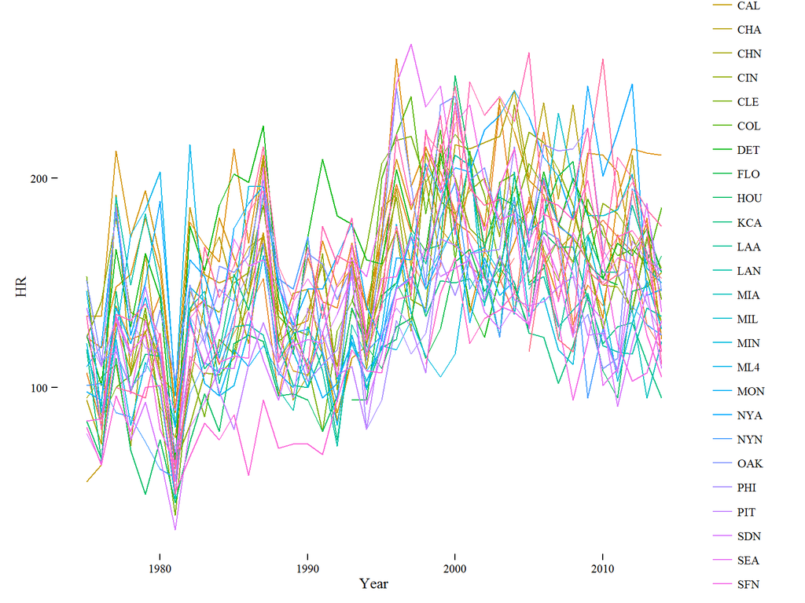

```r
library(ggplot2)
library(ggthemes)

HR_Time_Series = Batting_data%>%
  filter(yearID>=1975)%>%
  group_by(teamID, yearID)%>%
  summarise(HR = sum(HR, na.rm = TRUE))%>%
  ggplot()+
  geom_line(aes(x = yearID, y = HR, color = teamID))+
  theme_tufte()+
  xlab("Year")

HR_Time_Series
```

# Functions

Now you might say “Greg, that is way too many lines, and Home Runs are a terrible measure. Show me the Rangers’ and Astros’ runs.” Fair points. So we’ll need to construct a function to select the appropriate teams, as well as the correct measure.

### Evaluations

In order to write functions using dplyr code, you have to understand [Standard Evaluation vs. NSE (non-standard evaluation).](https://cran.r-project.org/web/packages/dplyr/vignettes/nse.html) Below is a short example, then I’ll demonstrate the correct (or at least a way that works) method on our baseball data set.

Here is what happens if you try to write the function as usual:

```r
group_iris <- function(grp_column, avg_column,df=iris){
  df2 <- df %>%
    group_by(grp_column) %>%
    summarise(count=sum(avg_column))
  return(df2)
}

group_iris(grp_column = "Species", avg_column = "Sepal.Length")
```

```
## Error in eval(expr, envir, enclos): unknown column 'grp_column'
```

Here is a working version:

```r
library(lazyeval)

group_iris <- function(grp_column, avg_column,df=iris ){
  df2 <- df %>%
    group_by_(grp_column)%>%
    summarise_(count= interp(~mean(col), col = as.name(avg_column)))
  return(df2)
}

group_iris(grp_column = "Species", avg_column = "Sepal.Length")
```

```
## Source: local data frame [3 x 2]
##
##      Species count
##       (fctr) (dbl)
## 1     setosa 5.006
## 2 versicolor 5.936
## 3  virginica 6.588
```

There are a couple of key differences:

1. Notice that each verb has and underscore at the end, so it’s summarise_ instead of summarise.
2. A little more obvious is the use of the interp function. Essentially you have use this combination to make sure R is looking for your column, instead of evaluating the string you provided.
3. Notice the ~ in front of the mean function. This is important to keep your environments straight.

Again, if you’re interested please read the link above. It was **VERY** helpful for me.

# A more complicated example

Now that you we have that covered. Let’s get back to our baseball example:

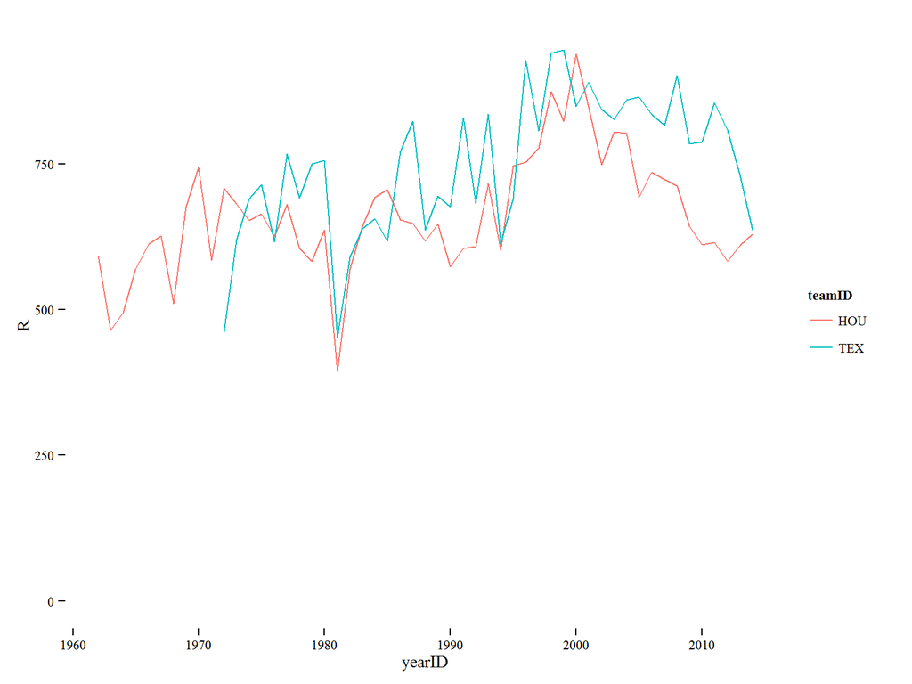

```r
library(ggplot2)
library(ggthemes)
StatPlotter = function(teamlist, stat, Min_Year = 1950, Max_Year = 2014){

   summary_stat = setNames(list(interp(~sum(var1, na.rm = TRUE), var1 = as.name(stat))), c(stat))

  filters = list(~teamID %in% teamlist,
                 ~yearID >= Min_Year,
                 ~yearID <= Max_Year)

  Batting_data%>%
    filter_(.dots = filters)%>%
    group_by_(~teamID, ~yearID)%>%
    summarise_(.dots = summary_stat)%>%
    ggplot()+
    geom_line(aes_string(x = "yearID", y = stat, color = "teamID"), stat = "identity")+
   expand_limits(y = 0)+
  theme_tufte()

}


StatPlotter(teamlist = c("TEX", "HOU"), stat = "R")
```

There are a couple of extra concepts in here:

1. The setNames function
   - This is used so that your output will have the correct name. In this case showing “R” instead of a constant arbitrary name like “Stat”
2. The .dots argument
   - You’ll need to use this if you want to change your output based on an argument. Which we are doing because are changing the name of the output column.

# Interactive Graphs with HTML Widgets

Switching gears a bit, R also has great functionality as it pertains to interactive graphics. It is surprisingly straight forward. Using the package htmlwidgets and several helper packages you can make interactive graphs with just a few lines of code. [Here is a good website for reference](http://www.htmlwidgets.org/)

Here is an example using the metrics graphics package:

```r
library(htmlwidgets)
library(metricsgraphics)

Career_Stolen_Bases = Batting_data%>%
  group_by(playerID)%>%
  summarise(Career_Stolen_Bases = sum(SB, na.rm = TRUE),
            Career_Caught_Stealing = sum(CS, na.rm=TRUE),
            Seasons = n_distinct(yearID))%>%
  left_join(y = Player_data, by = c("playerID" = "playerID"))%>%
  mutate(Name = paste(nameLast, nameFirst, sep = ", "),
         Height = paste(height%/%12, "'", height%%12, "\"", sep = ""))%>%
  select(Name, Height, Seasons,
         Career_Stolen_Bases, `Caught Stealing`=Career_Caught_Stealing)
#This is all the code to generate the graphic
mjs_plot(Career_Stolen_Bases, x=Seasons, y=Career_Stolen_Bases) %>%
  mjs_point()%>%
  mjs_labs(x="Seasons Played", y="Stolen Bases")%>%
   mjs_add_mouseover("function(d, i) {
                $('{{ID}} svg .mg-active-datapoint')
                    .text (d.point.Name + '  Seasons Played:' + d.point.Seasons + ' Stolen Bases:' + d.point.Career_Stolen_Bases);
  }")
```

[output not shown]

# Time series graphs

The package [dygraph package](https://rstudio.github.io/dygraphs/gallery-series-highlighting.html) produces some really good time series plots:

```r
library(dygraphs)
library(xts)
library(tidyr)

Stolen_Base_TS= Batting_data %>%
  filter(playerID %in% Stolen_Base_Seasons$playerID)%>%
  group_by(yearID, playerID)%>%
  summarise(Stolen_Bases = sum(SB, na.rm = TRUE))%>%
  left_join(y = Player_data, by = c("playerID" = "playerID"))%>%
  mutate(Name = paste(nameLast, nameFirst, sep = ", "),
         Year = as.Date(as.character(yearID), format = "%Y"))%>%
  ungroup()%>%
  select(Year, Name, Stolen_Bases)%>%
  spread(key = Name, value = Stolen_Bases)


SB_XTS = xts(Stolen_Base_TS, order.by = Stolen_Base_TS$Year)
SB_XTS$Year = NULL

dygraph(SB_XTS)%>%
  dyRangeSelector()%>%
  dyHighlight(highlightCircleSize = 5,
              highlightSeriesBackgroundAlpha = 0.2,
              hideOnMouseOut = TRUE)
```

[interactive chart not shown]

You’ll notice here I made use of two addtional packages:

1. [tidyr](http://blog.rstudio.org/2014/07/22/introducing-tidyr/) which is great for cleaning up data and stacking and unstacking data. I would also encourage you to read Hadley’s paper on [Tidy Data](http://vita.had.co.nz/papers/tidy-data.pdf). It does a good job of classifying common data problems and offering solutions.
2. xts, which stands for xstensible time series, is an extension of the zoo package and is necessary for dygraphs.

# Datatables

You’ve already seen a few examples of data tables earlier. They come from the package [DT](http://rstudio.github.io/DT/), and only take a couple lines to produce.

```r
datatable(head(Salary_data,10), options = list(pageLength = 5))
```

|  | yearID | teamID | lgID | playerID | salary |
| --- | --- | --- | --- | --- | --- |
| 1 | 1985 | ATL | NL | barkele01 | 870000 |
| 2 | 1985 | ATL | NL | bedrost01 | 550000 |
| 3 | 1985 | ATL | NL | benedbr01 | 545000 |
| 4 | 1985 | ATL | NL | campri01 | 633333 |
| 5 | 1985 | ATL | NL | ceronri01 | 625000 |
| 6 | 1985 | ATL | NL | chambch01 | 800000 |
| 7 | 1985 | ATL | NL | dedmoje01 | 150000 |
| 8 | 1985 | ATL | NL | forstte01 | 483333 |
| 9 | 1985 | ATL | NL | garbege01 | 772000 |
| 10 | 1985 | ATL | NL | harpete01 | 250000 |

My only caution is not to try and produce a giant data table, as it can eat memory pretty quickly and produce some error messages

# Thanks for letting me present

I had a fun time putting this together. Please let me know if you have any questions now or in the future.